# Red Wine Quality Data Analysis by Paul Hsiao

# Bivariate Analysis

### Talk about some of the relationships you observed in this part of the investigation. How did the feature(s) of interest vary with other features in the dataset?

From the Scatterplot matrices, the following are observed:

1. fixed.acidity and density have positive Correlation Coefficient of 0.668.
2. fixed.acidity and pH have negative Correlation Coefficient -0.683. This is expected as higher acidity will decrease the pH value.
3. The rest of the correlations are weak. None of the features has high correlation with quality directly.
4. The scatterplots with smoother have reinforce the above observations.
5. The boxplots show some interesting points for the wine with high rating quality. From the boxplots, the following are observed for the quality 8 wines:
1. Low pH value
2. Low residual sugar
3. High alcohol
4. Low chlorides
5. Low total.sulfur.dioxide
6. Low density

### Did you observe any interesting relationships between the other features (not the main feature(s) of interest)?

free.sulfur.dioxide and total.sulfur.dioxide have a positive Correlation Coefficient of 0.668. However, this is not a surprise as free.sulfur.dioxide is included in total.sulfur.dioxide.

### What was the strongest relationship you found?

fixed.acidity and pH have the highest Correlation Coefficient -0.683. Wine makers can adjust the pH level, ie. fixed acidity level, so their wine can satisfy consumer’s taste. In this dataset, the median pH level is 3.310.

# Multivariate Plots Section

Note: To give better presentation and avoid confusion, some of the following plots have partial quality value included in one plot.

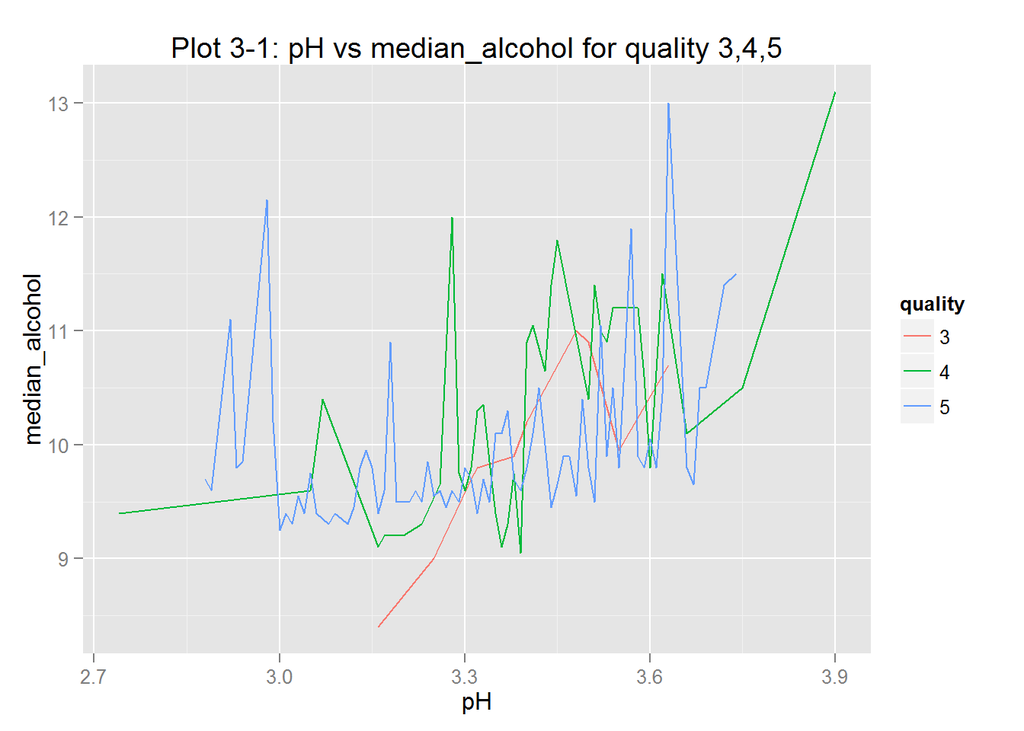

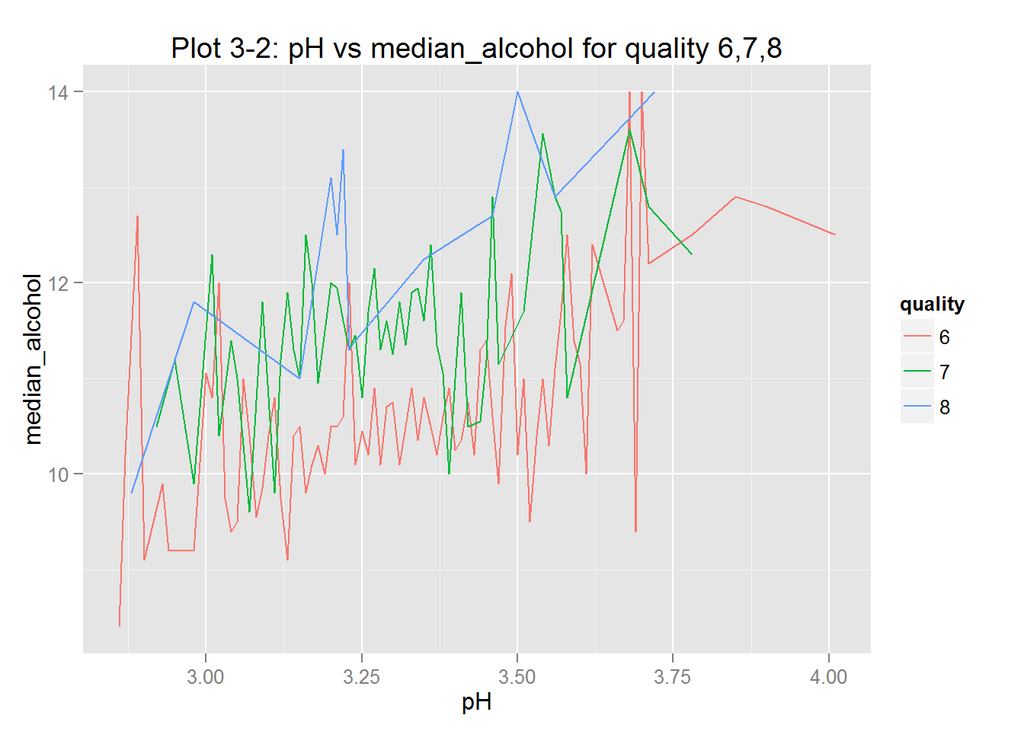

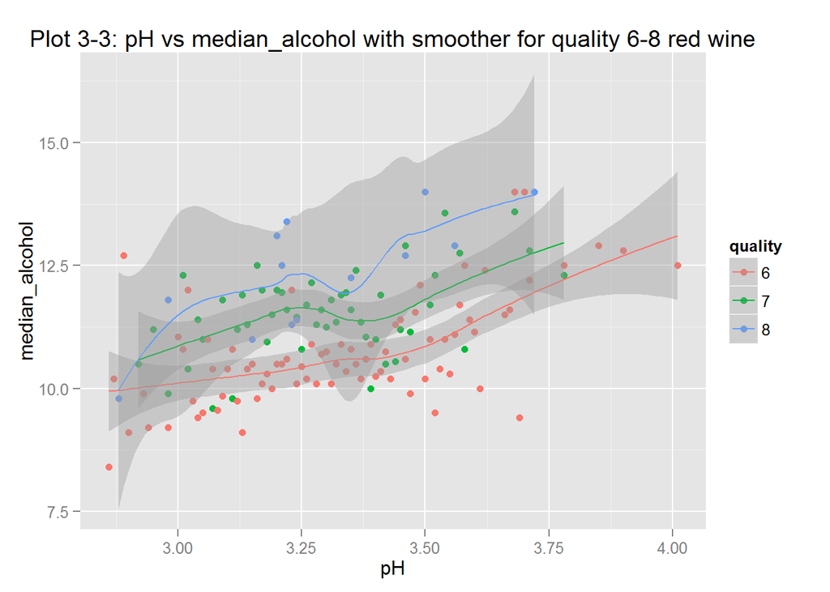

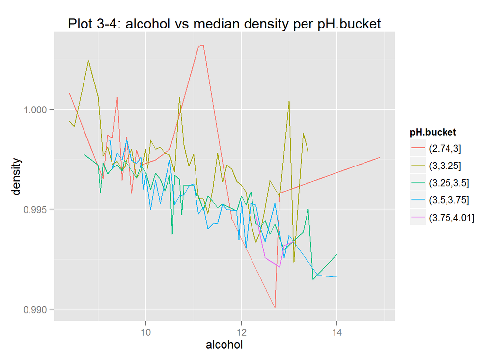

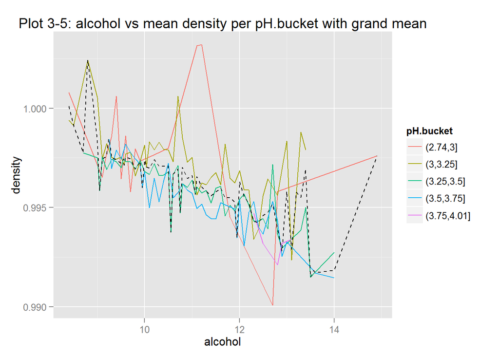

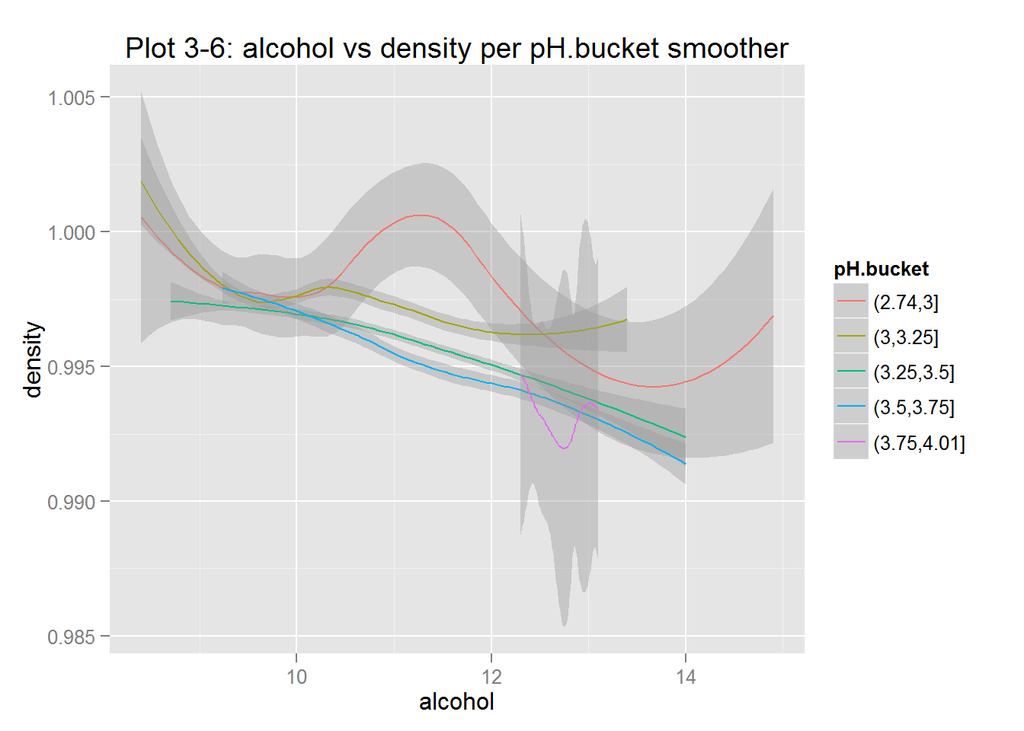

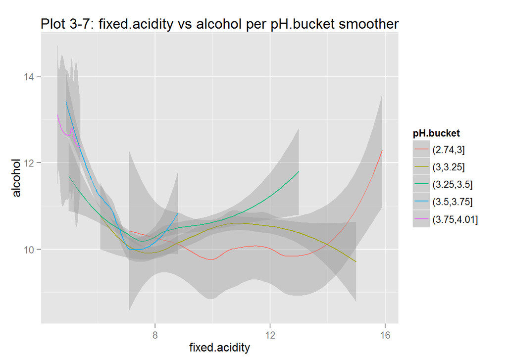

```
##
## Calls:
## m1: lm(formula = I(quality) ~ I(pH), data = reddf)
## m2: lm(formula = I(quality) ~ I(pH) + density, data = reddf)
## m3: lm(formula = I(quality) ~ I(pH) + density + fixed.acidity, data = reddf)
## m4: lm(formula = I(quality) ~ I(pH) + density + fixed.acidity + alcohol,
##     data = reddf)
## m5: lm(formula = I(quality) ~ I(pH) + density + fixed.acidity + alcohol +
##     residual.sugar, data = reddf)
##
## ===========================================================================
##                     m1          m2          m3          m4          m5
## ---------------------------------------------------------------------------
## (Intercept)       6.636***  101.930***   213.196***  29.491      24.579
##                  (0.433)    (11.256)     (13.348)   (17.324)    (21.430)
## I(pH)            -0.302*     -0.696***     0.824***  -0.419*     -0.443*
##                  (0.131)     (0.136)      (0.169)    (0.178)     (0.189)
## density                     -94.297***  -213.161*** -26.811     -21.802
##                             (11.130)     (13.595)   (17.610)    (21.807)
## fixed.acidity                              0.262***   0.065**     0.061*
##                                           (0.019)    (0.022)     (0.025)
## alcohol                                               0.356***    0.361***
##                                                      (0.023)     (0.027)
## residual.sugar                                                   -0.006
##                                                                  (0.015)
## ---------------------------------------------------------------------------
## R-squared            0.003       0.046       0.148       0.257       0.257
## adj. R-squared       0.003       0.045       0.146       0.255       0.255
## sigma                0.806       0.789       0.746       0.697       0.697
## F                    5.340      38.678      92.403     137.741     110.165
## p                    0.021       0.000       0.000       0.000       0.000
## Log-likelihood   -1923.965   -1888.793   -1798.518   -1689.282   -1689.205
## Deviance          1038.692     993.987     887.857     774.470     774.396
## AIC               3853.930    3785.586    3607.036    3390.563    3392.411
## BIC               3870.062    3807.095    3633.922    3422.826    3430.051
## N                 1599        1599        1599        1599        1599
## ===========================================================================
```

Plot 3-1 and 3-2 show the line plot of pH vs median alcohol per quality. Plot 3-3 uses smoother to show the trend of pH vs median alcohol per quality. Plot 3-4 and 3-5 show alcohol vs median/mean density per pH.bucket. Plot 3-6 and 3-7 use smoother to show the trend for alcohol vs density and fixed.acidity vs alcohol per pH.bucket. After the plot, the linear model is used to show model summary.

# Multivariate Analysis

### Talk about some of the relationships you observed in this part of the investigation. Were there features that strengthened each other in terms of looking at your feature(s) of interest?

From plot 3-1, 3-2 and 3-3, it is observed the pH and median_alcohol has positive correlation. From plot 3-4 and 3-5, it is observed the alcohol and density has negative correlation.

### OPTIONAL: Did you create any models with your dataset? Discuss the strengths and limitations of your model.

Yes, I did create a model. The strength is it has low p value. However, the R-squared is quite low.

# Final Plots and Summary

### Plot One

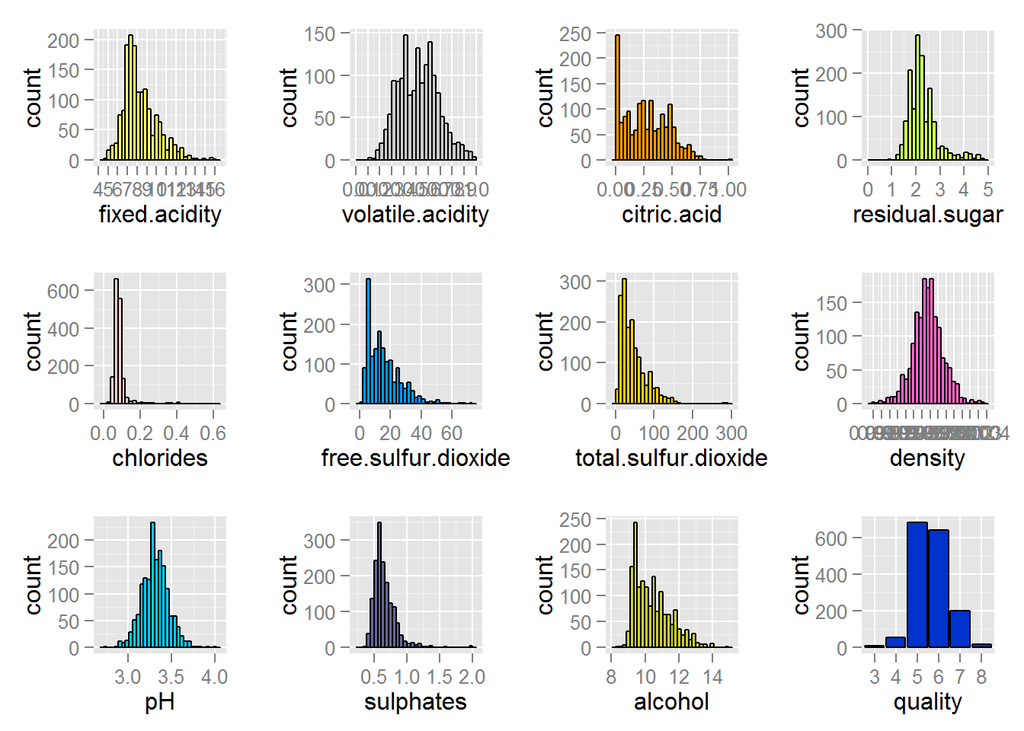

### Description One

This is the grid of histograms of all features. It show the distribution of each feature in the dataset. This plot provides the general idea about the dataset variable distribution, rather than detailed propotion of each feature.

### Plot Two

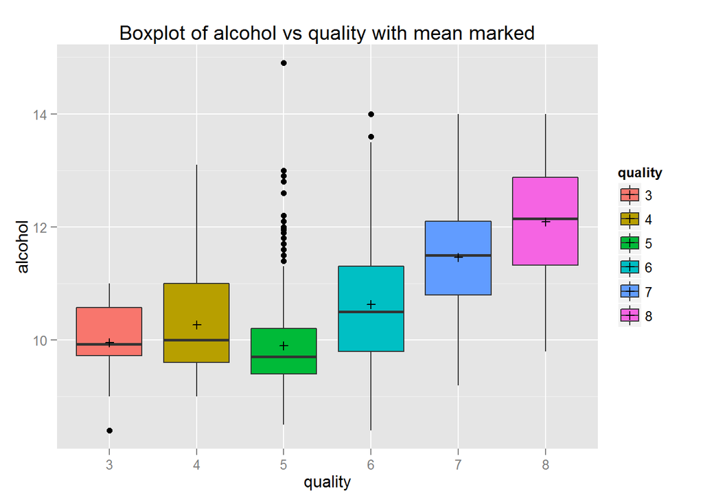

### Description Two

This plot clearly demonstrates the relationship between alcohol and quality. Even though the quality depends on other features as well, the plot shows the higher alcohol level is correlated to higher quality value in general.

### Plot Three

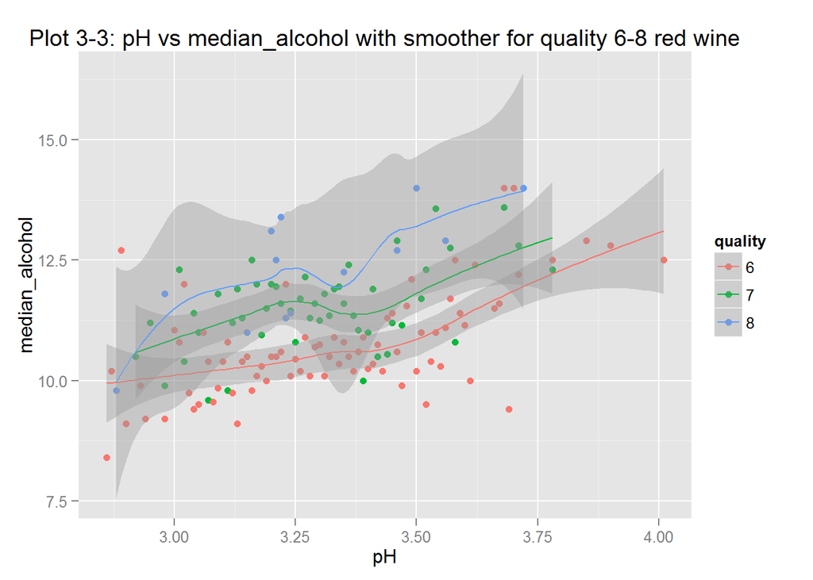

### Description Three

This plot shows the pH vs median_alcohol trend. Same observation from earlier plot repeats here - higher alcohol level linked to higher quality value for the same pH value.

# Reflection

It is a interesting subject to explore using the Data Analysis we learnt in this course. Without knowing much about the relationship between features, it was a bit hard to pick the features of interest in the begining. However, once I went through the Univariate, bivariate and multivariate ploting involving different feature combinations, the picture is more clear. Even though there is no definite conclusion from the analysis, a few key observations did provide us a good picture for the relationship of quality and interested features. There are still a lot of plotting technics we have not applied during the course yet. Even though the dataset provides only limited features in red wine, I believe with further exploring using more plotting technics, we can be more certain about the relationship between quality and features.